# Examen Parte 2

Chávez García Ángel Yair

2/10/2021

##### Se esta usando R Markdown para facilitar el uso de codigo R y realizar mas facilmente la graficación y la función de minimos cuadrados y ademas se utilizo Sage para resolver un sistema de ecuaciones, se agrega tambien un link a github donde encotra el archivo funte de este pdf generado apartir de un html y codigo utilizado para generar entradas, ademas de funciones en c++ para medir el tiempo y el codigo funte de la implementación del algoritmo llamado “findN.cpp”

[Link a github](https://github.com/Angel19901/ExamenParte_2)

**Pseudocodigo:**

binarySearchRightest( A, left, right, Target){

```
L <- left;
R <- right;

while (L < R)
    m <- floor((L + R) / 2);

    if (A[m] > Target)
        R <- m;
    else
        L <- m + 1;

return R;
```

}

N_esimo( A, B, Nesimo){

```
n <- B.size();
l <- min(B[0], A[0]);
r <- max(A[n - 1], B[n - 1]);
ans <- r + 1;


while (l <= r)
    m <- floor((l + r) / 2);

    SumDistance <- binarySearchRightest(A, 0, n, m);
    SumDistance <- SumDistance + binarySearchRightest(B, 0, n, m);

    if (SumDistance >= Nesimo)
        ans = min(ans, m);
        r <- m - 1;
    else
        l <- m + 1;

return ans;
```

}

**Argumento:**

binarySearchRightest

loopInvariant: Parte el arreglo en dos intervalos y descarta una de ellas para encontrar un valor igual o cercano al que se desea encontrar

```
1. Initialization: parte el arreglo en dos y checa si el elemnto de enmedio es el numero buscados, o elige un nuevo espacio de busqueda

2. Maintenance: Sigue partiendo y descartando intervalos mas pequeños

3. Termination: Termina cuando encuentra el numero buscado o hasta que el intervalo es de tamaño uno
```

N-esimo

loopInvariant: realiza una busqueda por intervalos hasta encontrar un indice que sea igual sea Igual N-esimo y retorna el valor que se busca

[output not shown]

**Tiempo de ejecución:**

Codigo 1

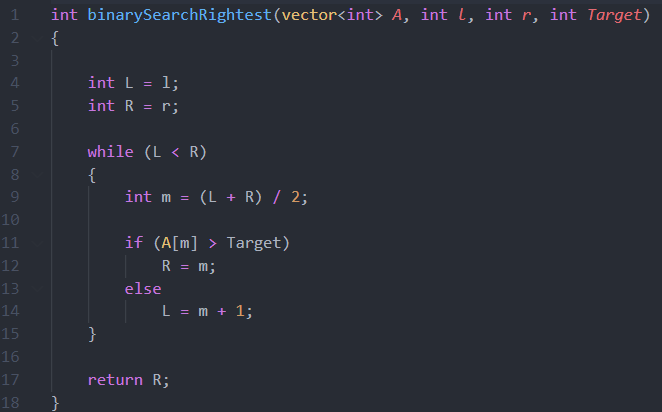

Codigo 2

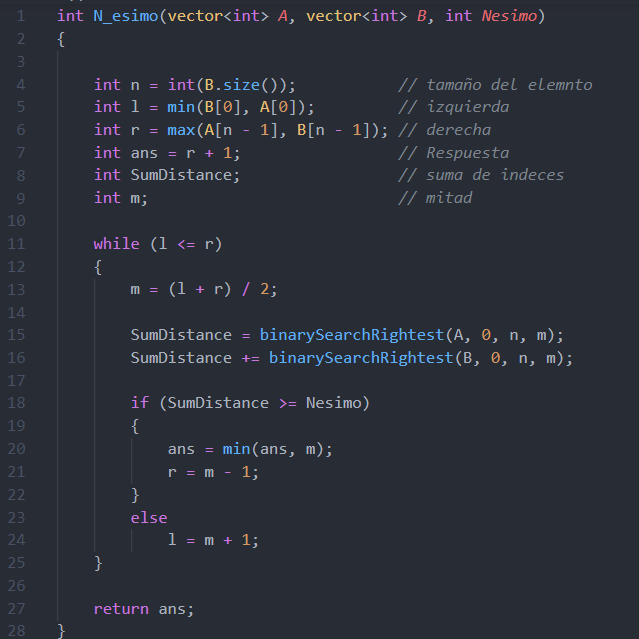

Codigo 1

De la linea 7 a 15 nos la dara la linea 9, que sera: $\theta(1)$ Esa linea se ejecutara k veces, y se ejecutara hasta que el arreglo sea igual a 1
$$\frac{n}{2^k}$$
$$\frac{n}{2^k} = 1$$
$$n = 2^k$$
$$lg(n) = k$$
esa sera la cumplejidad de la linea 7 a 15 $\theta(lg(n))$

La linea 17 sera $\theta(1)$

Complejidad Total:
$$O(lg(N))$$

Codigo 2

la linea 4 a 9 son $\theta(1)$

la linea 11 a 25

linea 13 $\theta(1)$ pasara lo mismo que con el que con el codigo 1 el cual se ejecutara k veces hasta que el intervalo sea 1 osea que lo que esta adentro del while sera $\theta(lg(n))$

linea 15 a 16 son $\theta(lg(max(S[ i ],T[ i ]), min(S[i],T[i])) * log(n))$ en el caso que que la diferencia del maximo elemento de S Y T menos el minimos de S y T sea 2n la complejidad sera $\theta(lg(n)^2)$

Lineas 18 a 24 seran $\theta(lg(n))$

Linea 27 sera $\theta(lg(1))$

El algoritmos sera complejidad
$$O(lg(n)^2)$$

si la direncia entre el maximo y el minimo es 2n en otro caso sera
$$O(lg(max(S[i],T[i]) - min(S[i],T[i])) * lg(n))$$

**Implementación en c++**

$$Inicio$$
#include <bits/stdc++.h>

using namespace std;

/* Busqueda binaria para encontrar el elemnto mas a la derecha de un arreglo A = [1,2,3,4,5,6,7,7,7,7,7,7,8] ^ | Si lo ejecutara upperBound(A,0,A.size(), 7) encontraria ese ultimo 7

*/

int binarySearchRightest(vector A, int l, int r, int Target) {

```
 int L = l;
 int R = r;

 while (L < R)
 {
     int m = (L + R) / 2;

     if (A[m] > Target)
         R = m;
     else
         L = m + 1;
 }

 return R;
```

}

int N_esimo(vector A, vector B, int Nesimo) {

```
 int n = int(B.size());           // tamaño del elemento
 int l = min(B[0], A[0]);         // izquierda
 int r = max(A[n - 1], B[n - 1]); // derecha
 int ans = r + 1;                 // Respuesta
 int SumDistance;                 // suma de indeces
 int m;                           // mitad

 while (l <= r)
 {
     m = (l + r) / 2;

     SumDistance = binarySearchRightest(A, 0, n, m);
     SumDistance += binarySearchRightest(B, 0, n, m);

     if (SumDistance >= Nesimo)
     {
         ans = min(ans, m);
         r = m - 1;
     }
     else
         l = m + 1;
 }

 return ans;
```

}

int main() {

```
 printf("**************************************************************************************************\n");
 printf("*NOTA:                                                                                           *\n");
 printf("* Si quieres que este algoritmo sea O(( lg(n) )^2)                                               *\n");
 printf("* Entonces coloca valores K, K + 1, K + 2, ..., K + 2 n - 1                                      *\n");
 printf("* k = minimo valor entre tus dos arreglos, n = tamanio de tus arreglos                           *\n");
 printf("* En otro caso este algoritmo sera 0( lg( max(S[ i ],T[ i ]) - min(S[ i ], T[ i ] ) ) * lg(n) )  *\n");
 printf("**************************************************************************************************\n");
 printf("\n\nPresiona cualquier letra de tu teclado para continuar... ");
 getchar();

 int n;
 printf("\n\ningrese el tamanio de su arreglo: ");
 scanf("%d", &n);
 printf("\n");
 getchar();
 // Crea Arreglo de tamaño n con valores de cero
 vector<int> S(n, 0);
 vector<int> T(n, 0);
 /*Llena el arreglo */

 printf("Llene sus dos arreglos.\n");
 printf("Sus arreglos ya deben estar ordenados\n");

 for (int i = 0; i < n; i++)
 {
     printf("Llene el arreglo en la posicion S[ %d ] ", i + 1);
     scanf("%d", &S[i]);
     printf("\n");
     getchar();
 }

 for (int i = 0; i < n; i++)
 {
     printf("Llene el arreglo en la posicion T[ %d ] ", i + 1);
     scanf("%d", &T[i]);
     printf("\n");
     getchar();
 }

 /*Encuentra el Nesimo elementos*/
 printf("El enesimo es: %d\n", N_esimo(S, T, n));

 return 0;
```

}
$$Fin$$

Datos obtenidos de medir el tiempo del algoritmo. “x” es el tamaño de la entrada “y” el tiempo de ejecuión.

```r
x =
c(10.0, 100.0, 1000.0, 10000.0, 11000.0, 12000.0, 13000.0, 14000.0, 15000.0, 16000.0, 17000.0, 18000.0, 19000.0, 20000.0, 21000.0, 22000.0, 23000.0, 24000.0, 25000.0, 26000.0, 27000.0, 28000.0, 29000.0, 30000.0, 31000.0, 32000.0, 33000.0, 34000.0, 35000.0, 36000.0, 37000.0, 38000.0, 39000.0, 40000.0, 41000.0, 42000.0, 43000.0, 44000.0, 45000.0, 46000.0, 47000.0, 48000.0, 49000.0, 50000.0, 51000.0, 52000.0, 53000.0, 54000.0, 55000.0, 56000.0, 57000.0, 58000.0, 59000.0, 60000.0, 61000.0, 62000.0, 63000.0, 64000.0, 65000.0, 66000.0, 67000.0, 68000.0, 69000.0, 70000.0, 71000.0, 72000.0, 73000.0, 74000.0, 75000.0, 76000.0, 77000.0, 78000.0, 79000.0, 80000.0, 81000.0, 82000.0, 83000.0, 84000.0, 85000.0, 86000.0, 87000.0, 88000.0, 89000.0, 90000.0, 91000.0, 92000.0, 93000.0, 94000.0, 95000.0, 96000.0, 97000.0, 98000.0, 99000.0, 100000.0)
y = c( 1.9883e-05, 1.2798e-05, 4.0385e-05, 0.0003582, 0.000332988, 0.000303383, 0.000229339, 0.00022946, 0.000255019, 0.000272535, 0.000305597, 0.000326992, 0.000337769, 0.000360907, 0.00037552, 0.000392634, 0.000421516, 0.0004405, 0.000447675, 0.000468981, 0.000483671, 0.000552741, 0.000529023, 0.000559679, 0.000583295, 0.000593123, 0.000733023, 0.00078444, 0.000783326, 0.000817272, 0.000817191, 0.000867188, 0.000874267, 0.000940511, 0.000954811, 0.00121475, 0.000867835, 0.00102403, 0.00105108, 0.00104086, 0.00109789, 0.0011025, 0.00116205, 0.00112972, 0.00122405, 0.00118857, 0.00127397, 0.00125582, 0.00131389, 0.00130255, 0.0013696, 0.00134284, 0.00144249, 0.00140191, 0.00169614, 0.00148265, 0.00155584, 0.00153168, 0.00159619, 0.00163807, 0.00171973, 0.0016987, 0.00178965, 0.00177008, 0.00184018, 0.00181979, 0.00188388, 0.0018977, 0.00216701, 0.00192594, 0.00202328, 0.00197333, 0.00211753, 0.00211308, 0.00216263, 0.00212932, 0.00226116, 0.00221635, 0.00225284, 0.0020045, 0.00231673, 0.00236348, 0.00236893, 0.00254268, 0.00242469, 0.00248488, 0.00245927, 0.00254075, 0.00253461, 0.00260603, 0.00260212, 0.0027065, 0.00264667, 0.00275511)
```

Minimos cuadrados para Y = a3(lg(x))^2 a2(lg(x)) + a1

primero que nada, hay que hacer un cambio de variable X´ = (lg(x)) luego tenemos Y = a3 (x´)^2 + a2 (x´) + a1 que es por minimos cuadrados para un polinimio

$$\sum_{1}^{94} (a_{3}(x'_{i})^{2} + a_{2}x'_{i} + a_{3} = y_{i})$$
$$\sum_{1}^{94} (a_{3}(x'_{i})^{3} + a_{2}(x'_{i})^{2} + a_{3}x'_{i} = x'_{i}y_{i})$$
$$\sum_{1}^{94} (a_{3}(x'_{i})^{4} + a_{2}(x'_{i})^{3} + a_{3}(x'_{i})^2 = (x'_{i})^2{}y_{i})$$
$(x')_{i}$ va ser representada en codigo con x_, log() en R es ln()

```r
x_  = log(x)/log(2)
```

```r
x_  = log(x)/log(2)

sumX_ = sum(x_)
sumY = sum(y)
sumX_2 = sum(x_^2)
sumX_3 = sum(x_^3)
sumX_4 = sum(x_^4)
sumX_Y = sum(x_ * y)
sumX_2Y = sum(x_^2 * y)
print(sumX_)
```

```
## [1] 1433.114
```

```r
print(sumY)
```

```
## [1] 0.1242317
```

```r
print(sumX_2)
```

```
## [1] 22168.34
```

```r
print(sumX_3)
```

```
## [1] 345244.4
```

```r
print(sumX_4)
```

```
## [1] 5399972
```

```r
print(sumX_Y)
```

```
## [1] 1.984922
```

```r
print(sumX_2Y)
```

```
## [1] 31.76631
```

Resolviendo el sistema de ecuaciones
$$22168.34 a_{3} + 1433.114 a_{2} + 94 a_{3} = 0.1242317$$
$$345244.4 a_{3} + 22168.34 a_{2} + 1433.114 a_{3} = 1.984922$$
$$5399972 a_{3} + 345244.4 a_{2} + 22168.34 a_{3} = 31.76631$$
Resolviendo el sistema de ecuaciones con Sage

$sage: x,y,z = var('x y z')$

$sage: Ecu1 = 5399972 * x + 345244.4 * y + 22168.34 * z == 31.76631$ $sage: Ecu2 = 345244.4 * x + 22168.34 * y + 1433.114 * z == 1.984922$ $sage: Ecu3 = 22168.34 * x + 1433.114 * y + 94 * z == 0.1242317$

$sage: solve([Ecu1,Ecu2,Ecu3],x,y,z)$

$[[x == (74791690299601/1210903941960450000), y ==(-108642954151199/96872315356836000), z == (829591996129/215271811904080)]]$

```r
a3 = 74791690299601/1210903941960450000
a2 = -108642954151199/96872315356836000
a1 = 829591996129/215271811904080
```

Ahora generamos X de 1 a 100000

```r
X = 1:100000
```

Generamos Y con los valores encontrados

```r
Y = a3 * (log(X)/log(2))^2 + a2 * (log(X)/log(2)) + a1
```

graficas del algorimo en azul y minimos cuadrados en rojo

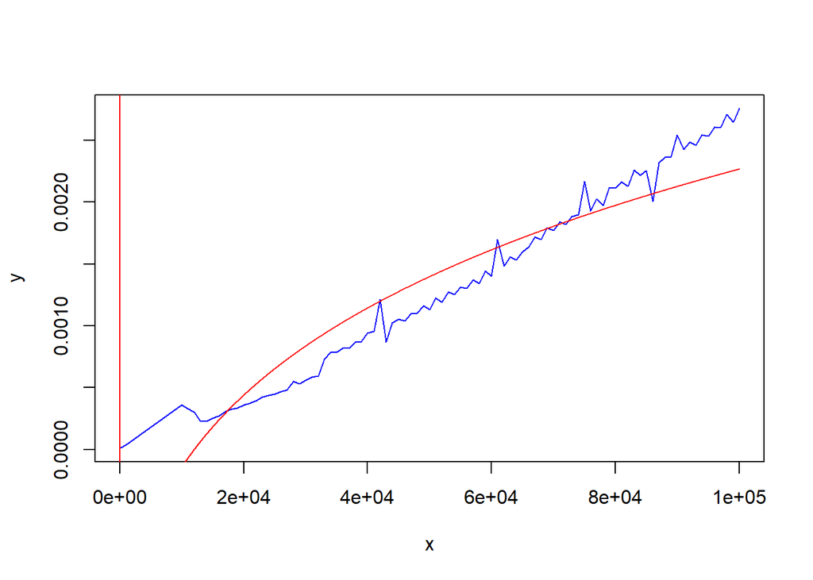

```r
plot(x,y,type='l',col='blue')
lines(X,Y,col='red')
```